# hw5

1. Load the usual Iris data restricted to the first two features, and ignore the class / target variable. Plot the data and see for yourself how “clustered” you think it looks. Include the plot, and mention how many clusters you think exist (no wrong answer here). (5 points)

```python
import matplotlib.pyplot as plt
import numpy as np
import mltools as ml
```

```python
iris = np.genfromtxt("data/iris.txt",delimiter=None)
```

```python
iris2 = iris[:, 0:2]
feat1 = iris2[:, 0]
feat2 = iris2[:, 1]
```

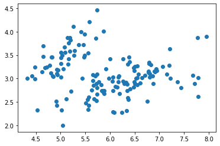

```python
plt.scatter(feat1, feat2)
```

This looks relatively clustered to me. I think there are 2 clusters.

2) Run k-means on the data, for k = 2, k = 5, and k = 20. Try a few (at least 5 each) different initializations and check to see whether they find the same solution; if not, pick the one with the best score. For the chosen assignment for each k, include a plot with the data, colored by assignment, and the cluster centers. You can plot the points colored by assignments using ml.plotClassify2D(None,X,z), where z are the resulting cluster assignments of the data. You will have to additionally plot the centers yourself.

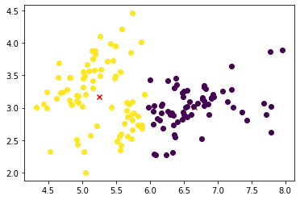

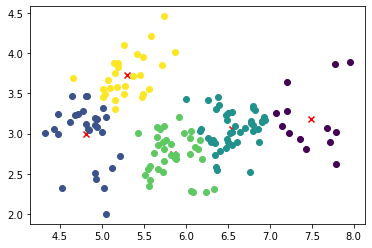

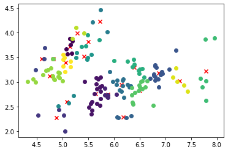

```python
K = [2, 5, 20]
for k in K:
    km_z, km_c, km_sumd = ml.cluster.kmeans(iris2, k)
    plt.figure()
    ml.plotClassify2D(None, iris2, km_z)
    plt.scatter(*zip(*km_c), c = "red", marker = "x")
```

3) Run agglomerative clustering on the data, using single linkage and then again using complete linkage, each with 2, 5, and then 20 clusters (using ml.cluster.agglomerative from cluster.py). Again, plot with color the final assignment of the clusters. (This algorithm has no initialization issues; so you do not have to try multiple initializations.)

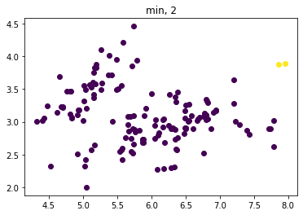

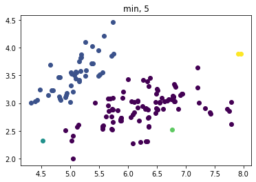

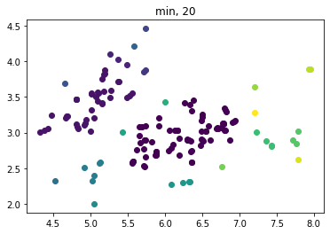

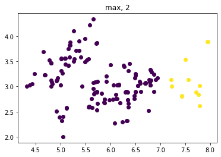

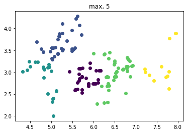

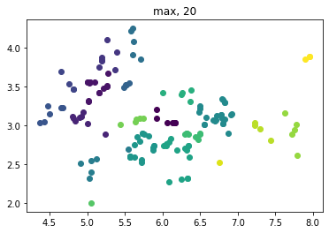

```python
#run with method = min, method = max for single & complete linkage
K = [2, 5, 20]
mthd = ["min", "max"]
for m in mthd:
    for k in K:
        km_z, km_join = ml.cluster.agglomerative(iris2, k, method = m)
        plt.figure()
        title = str(m) + ", " + str(k)
        plt.title(title)
        ml.plotClassify2D(None, iris2, km_z)
    #plt.scatter(*zip(*km_c), c = "red", marker = "x")
```

# Single linkage: we merge the clusters whose two closest members have minimum distance.

# Complete linkage: distance between clusters is the furthest distance among members.

4) Describe similarities and differences in the results from the agglomerative clustering and k-means.

The results from k-means are generally more intuitive, and I think probably better. With single linkage agglomerative clustering, we end up with clusters that are pointlessly small, like the yellow dot on k = 5. Between single and complete linkage, qualitatively complete linkage seems to have better results, that are more similar to k-means. Complete linkage is also more sensitive to the empty space inbetween clusters, while in single linkage you can get weird results that seem to ignore the spaces.

**EIGENFACES**

```python
X = np.genfromtxt("data/faces.txt", delimiter = None)
```

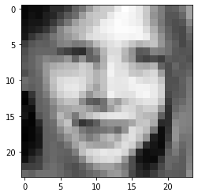

```python
img = np.reshape(X[1000, :], (24, 24))
plt.imshow(img.T, cmap = "gray")
```

1) Subtract the mean of the face images (X0 = X − µ) to make your data zero-mean. (The mean should be of the same dimension as a face, 576 pixels.) Plot the mean face. (5 points)

```python
mu= np.mean(X, axis=0, keepdims=True)
X0 = X - mu
print(mu.shape)
print(X0.shape)
```

```
(1, 576)
(4916, 576)
```

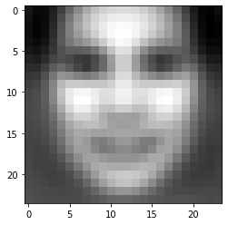

```python
img = np.reshape(mu, (24, 24))
plt.imshow(img.T, cmap = "gray")
```

2) Use scipy.linalg.svd to take the SVD of the data so that

X0 = U · diag(S) · Vh

Since the number of data is larger than the number of dimensions, there are at most 576 non-zero singular values; you can use full matrices=False to avoid using a lot of memory. As in the slides, we suggest computing W = U.dot( np.diag(S) ) so that X0 ≈ W · Vh. Print the shapes of W and Vh. (10 points)

```python
import scipy.linalg
```

```python
U, S, Vh = scipy.linalg.svd(X0, False)
W = U.dot(np.diag(S))
```

```python
print(W.shape)
```

```
(4916, 576)
```

```python
print(Vh.shape)
```

```
(576, 576)
```

3) For K = 1 . . . 12, compute the approximation to X0 given by the first K eigendirections, e.g., X0 = W[:, : K] · V h[: K, :], and use them to compute the mean squared error in the SVD’s approximation,np.mean( (X0 − Xˆ0)**2 ). Plot these MSE values as a function of K. (10 points)

```python
#If we use all of the eigenvectors
Xhat = U[:,0:k].dot(np.diag(S[0:k])).dot(Vh[0:k,:])
```

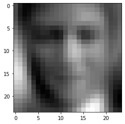

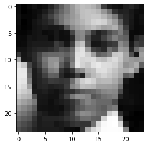

```python
img = np.reshape(Xhat[5], (24, 24))
plt.imshow(img.T, cmap = "gray")
plt.figure()
img = np.reshape(X[5], (24, 24))
plt.imshow(img.T, cmap = "gray")
plt.figure()
```

```python
np.mean((X0[0]-Xhat[0])**2)
```

```
2491.850827040584
```

```python
mse = []
for k in range(1, 13):
    Xhat = U[:,0:k].dot(np.diag(S[0:k])).dot(Vh[0:k,:])
    mse.append(np.mean((X0-Xhat)**2))
```

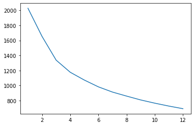

```python
plt.plot(np.arange(1, 13), mse)
```

4) Display the first three principal directions of the data, by computing µ+α V[j,:] and µ-α V[j,:], where α is a scale factor (we suggest, for example, 2*np.median(np.abs(W[:,j])), to get a sense of the scale found in the data). These should be vectors of length 242 = 576, so you can reshape them and view them as “face images” just like the original data. They should be similar to the images in lecture.

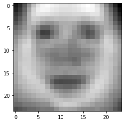

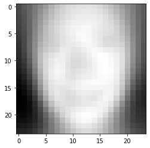

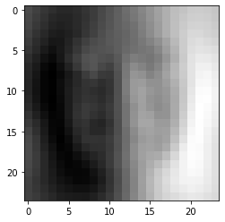

```python
j = 3
for j in range(3):
    alpha = 2*np.median(np.abs(W[:,j]))
    #d1 = mu + alpha*Vh[j,:]
    d2 = mu - alpha*Vh[j,:]
    plt.figure()
    #img = np.reshape(d1, (24, 24))
    #plt.imshow(img.T, cmap = "gray")
    #plt.figure()
    img = np.reshape(d2, (24, 24))
    plt.imshow(img.T, cmap = "gray")
```

5) Choose any two faces and reconstruct them using the first K principal directions, for K = 5, 10, 50, 100. (5 points)

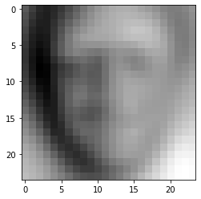

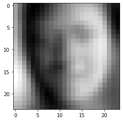

[figure not shown]

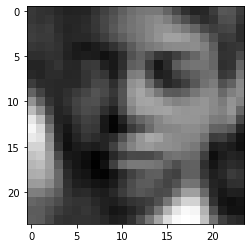

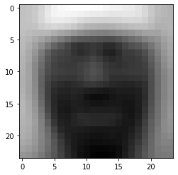

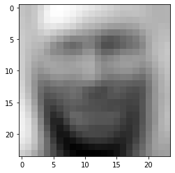

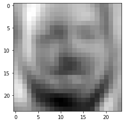

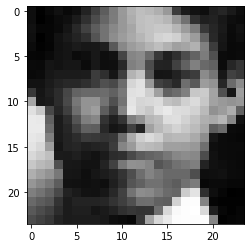

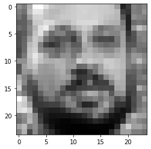

```python
K = [5, 10, 50, 100]
faces = [5, 124]
for f in faces:
    for k in K:
        reconstruction = np.dot(W[f,:k], Vh[:k,:])
        plt.figure()
        img = np.reshape(reconstruction, (24, 24))
        plt.imshow(img.T, cmap = "gray")

img = np.reshape(X[5], (24, 24))
plt.imshow(img.T, cmap = "gray")
plt.figure()
img = np.reshape(X[124], (24, 24))
plt.imshow(img.T, cmap = "gray")
```

6) Methods like PCA are often called “latent space” methods, as the coefficients can be interpreted as a new geometric space in which the data are being described. To visualize this, choose a few faces (say 25), and display them as images in a two-dimensional plane (as in the lecture), where the twodimensional coordinates are given by their coefficients on the first two principal components:

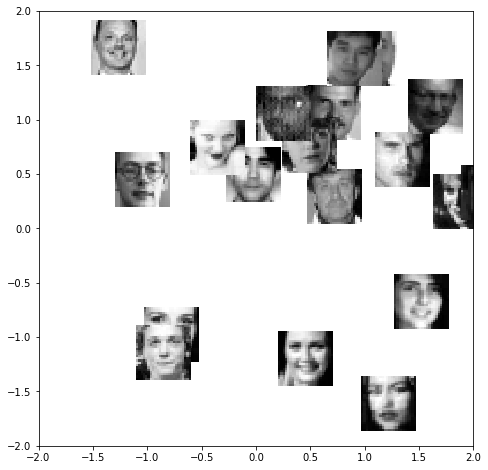

```python
idx = np.random.randint(low = 0, high = 4915, size = 20)
#idx = ... # pick some data (randomly or otherwise); an array of integerindices
import mltools.transforms
coord,params = ml.transforms.rescale(W[:,0:2]) # normalize scale of "W"locations
plt.figure(figsize=(8, 8));
#plt.hold(True); # you may need this for pyplot
for i in idx:
# compute where to place image (scaled W values) & size
    loc = (coord[i,0],coord[i,0]+0.5, coord[i,1],coord[i,1]+0.5)
    img = np.reshape( X[i,:], (24,24) ) # reshape to square
    plt.imshow( img.T , cmap="gray", extent=loc ) # draw each image
    plt.axis( (-2,2,-2,2) )
```

```python
X.shape
```

```
(4916, 576)
```

**COLLABORATION STATEMENT**

I worked alone!